# Time Series Forecasting

Siva Chandrasekar

November 19, 2017

# The Forecaster’s Toolbox

This repository for Forecasting Tutorial using Rob Hyndmann’s source

This project has all the codes that will be described in Rob Hyndmann’s tutorial available at https://www.otexts.org/fpp/2/4

QUESTIONS TO BE ASKED BEFORE FORECASTING:

- Are there consistent patterns?
- Is there a significant trend?
- Is seasonality important?
- Are there any outliers in the data that needs expertise’s knowledge?

CHOOSING AND FITTING MODELS:

- Always run different models to predict the forecast, and choose a best model out of the predicted models. Severl tests are available to measure the error’s, minimize the errors that will be discussed eventually.

```r
data <- read.csv(paste0(wd,"dataSet/SampleData.csv"), header = T)
tsdata <- data$tsValue
tsdata <- ts(tsdata, start = c(2010,9), end = c(2017,8), frequency = 12)

#head(tsdata)
```

## GRAPHICS:

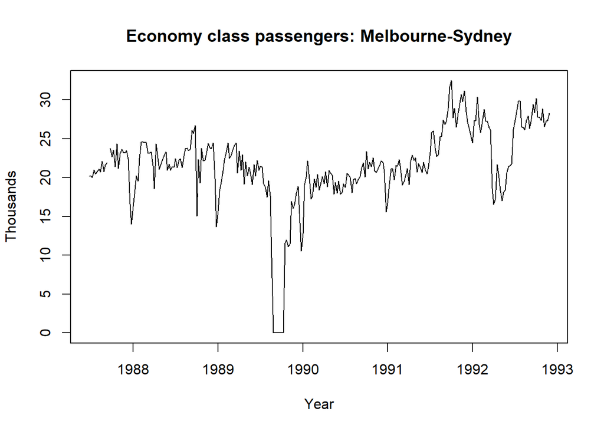

```r
load(paste0(wd,"dataSet/melsyd.rda"))

plot(melsyd[,"Economy.Class"],
     main="Economy class passengers: Melbourne-Sydney",
     xlab="Year",ylab="Thousands")
```

Looking at the plot for the Economy class, the following are evident at a first glance:

- No passengers have travelled during part of the period in 1989 - This is due to some industrial dispute (SME input)
- A period of reduced load in 1992
- A large increase in passenge load in end of 1991
- There are some large dips at the start of each year (holiday season)
- Long term flucutations: increasing in 1987, then decreasing in 1989, then again increasing through 1991, 1992

All the above observations should be accounted when building a model

```r
dygraph(tsdata, main = "Total Sales", ylab = "Sales in Mn") %>%
  dyRangeSelector() %>%
  dyAxis("x", label = "Period") %>%
  dyAxis("y", axisLabelFontSize = 10) %>%
  dySeries(label = "Total Sales in USD") %>%
  dyOptions(drawPoints=T, pointSize=3, maxNumberWidth = 20)
```

[interactive chart not shown]

A simpler time series data is available below:

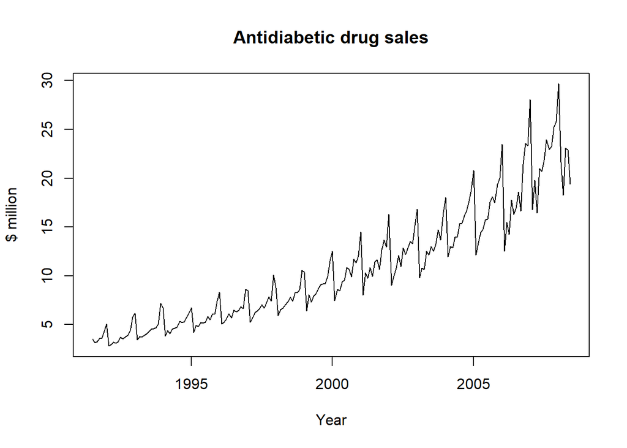

```r
load(paste0(wd,"dataSet/a10.rda"))

plot(a10,
ylab="$ million",
xlab="Year",
main="Antidiabetic drug sales")
```

### SEASONAL PLOT AND MONTH PLOT

These plots are mainly used to visualize the data by season or a cycle which provides better idea to the seasonality behind the data

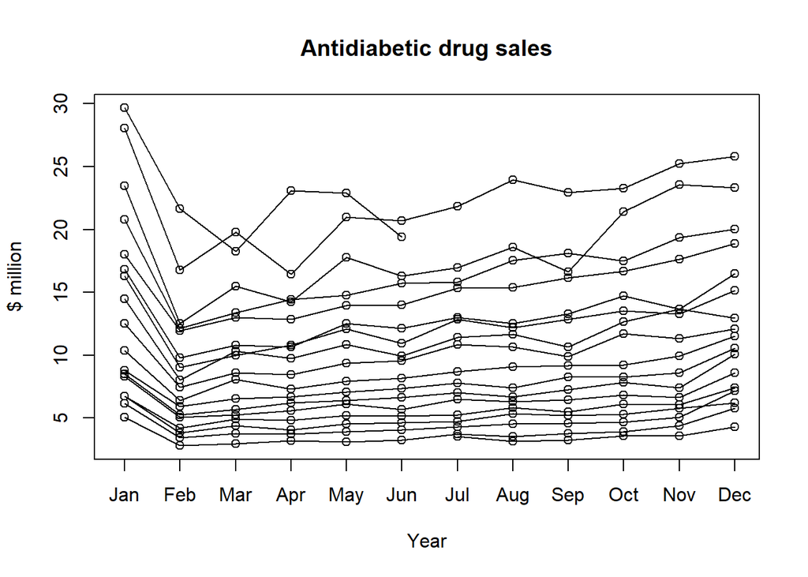

```r
#load("~/R Projects/Forecasting-Tutorial/dataSet/a10.rda")

seasonplot(a10,
ylab="$ million",
xlab="Year",
main="Antidiabetic drug sales")
```

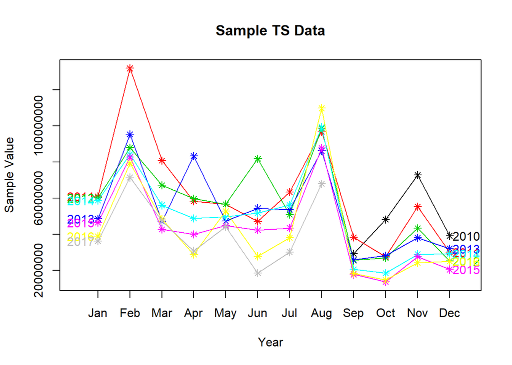

```r
seasonplot(tsdata,
     main = "Sample TS Data",
     xlab="Year",
     ylab="Sample Value",
     year.labels=TRUE,
     year.labels.left=TRUE,
     col = 1:8,
     pch=8)
```

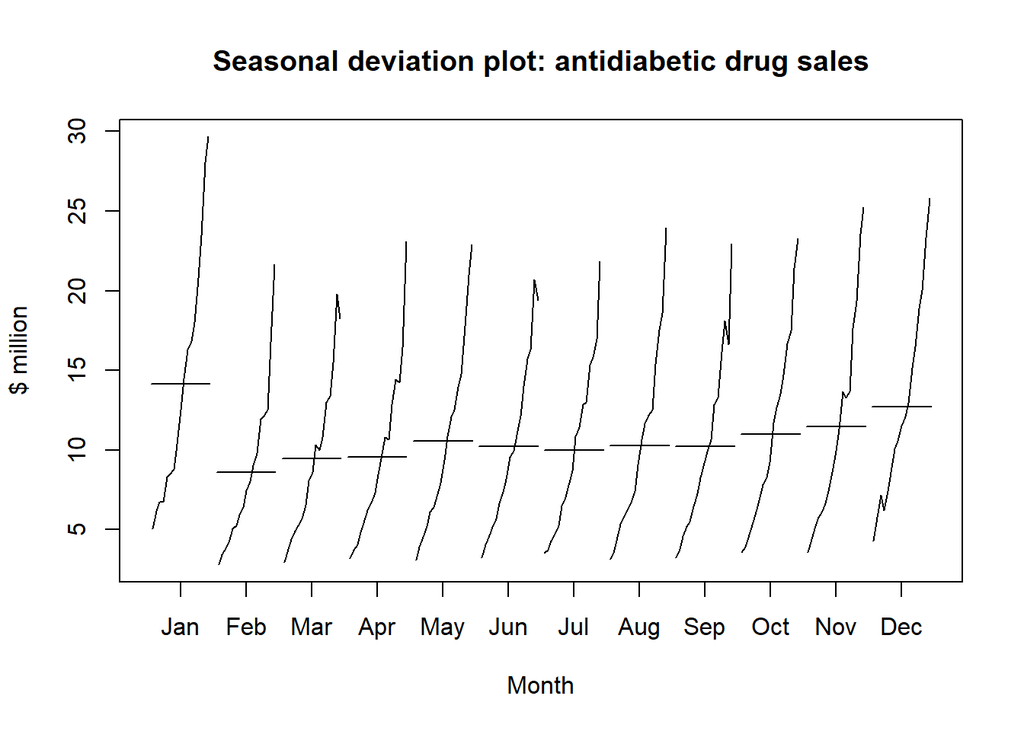

```r
monthplot(a10,ylab="$ million",xlab="Month",xaxt="n",
          main="Seasonal deviation plot: antidiabetic drug sales")
axis(1,at=1:12,labels=month.abb,cex=0.8)
```

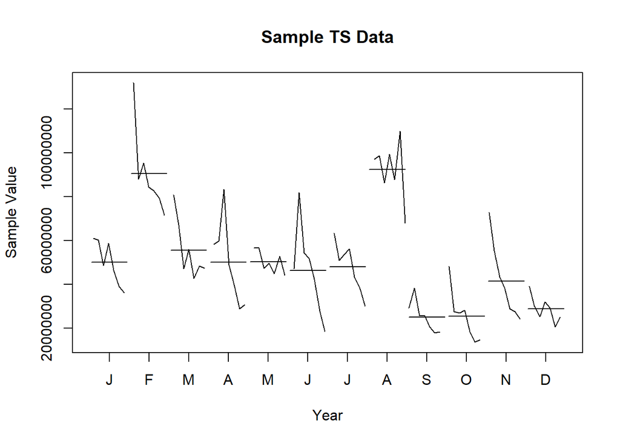

```r
monthplot(tsdata,
          main = "Sample TS Data",
     xlab="Year",
     ylab="Sample Value")
```

### SCATTER PLOT

Scatter plots are useful to find the **relations betweek variables**. These plots can also be useful to find the strength of the relationship between a predictor variable and predicted variable.

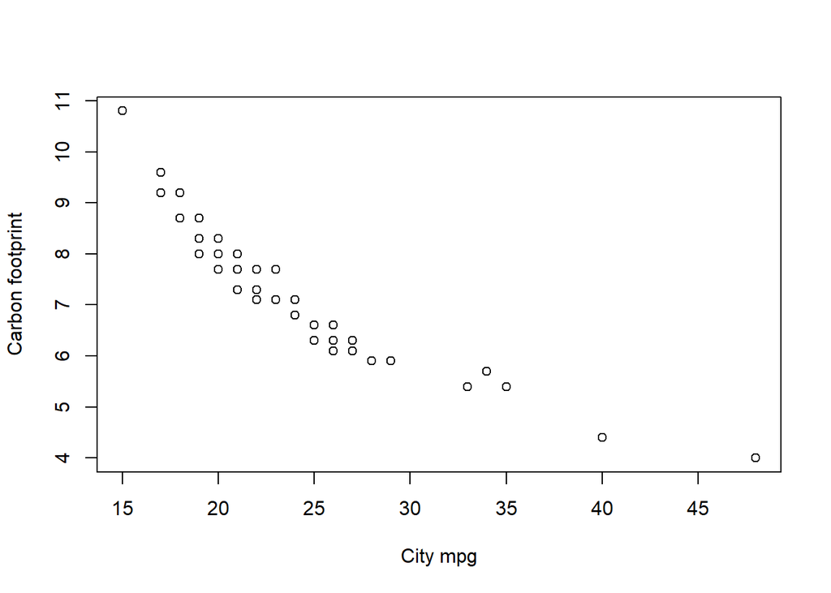

```r
plot(fuel[,5], fuel[,8], xlab="City mpg", ylab="Carbon footprint")
```

In a scatterplot, *jitter function* is useful to avoid any overlapping of the data points.

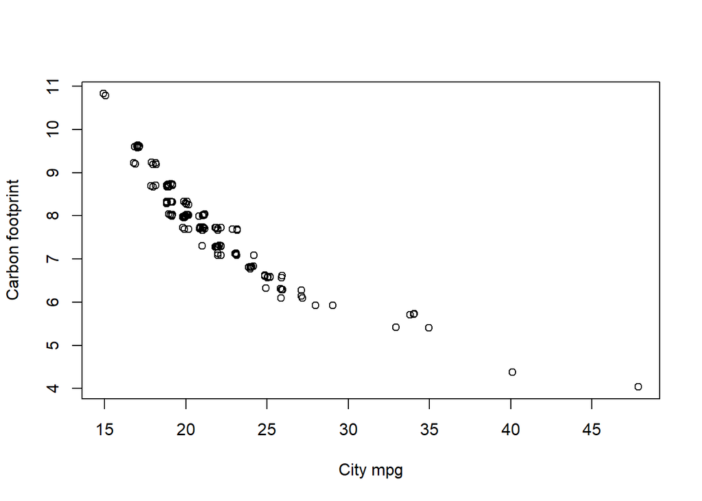

```r
plot(jitter(fuel[,5]), jitter(fuel[,8]), xlab="City mpg", ylab="Carbon footprint")
```

**Scatter Plot Matrices** are useful when there are more than two variables for which the relationship is to be determined.

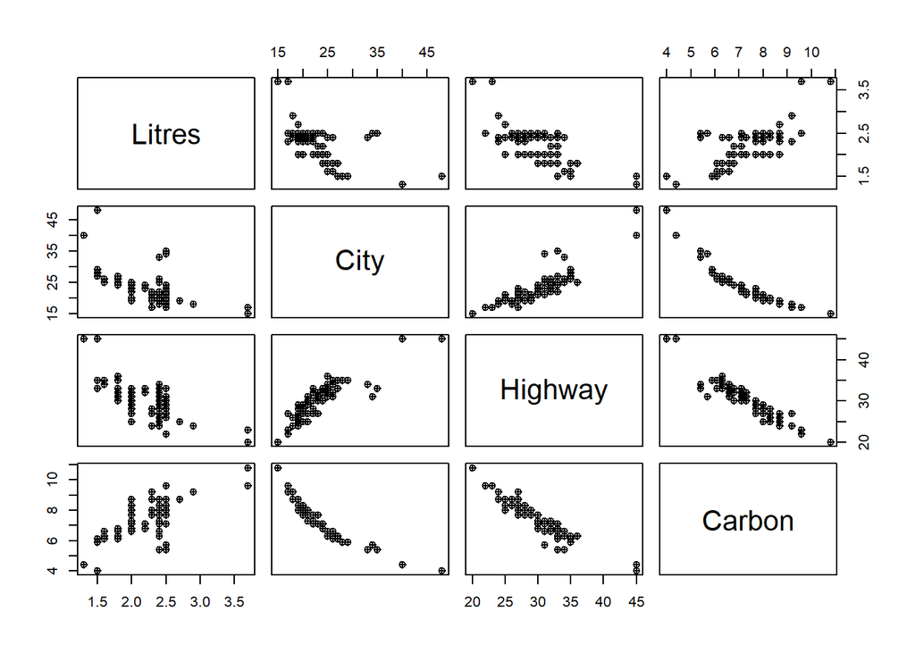

```r
pairs(fuel[,-c(1:2,4,7)], pch=10)
```

Note that scatter plots should be used with *continuous variables* for finding the relationship. Ordinal or factors do not provide much information.

## NUMERICAL DATA SUMMARIES

**Percentiles** are very useful for describing the distribution of the data.

```r
quantile(fuel$Carbon, probs = .1)
```

```
## 10%
## 6.3
```

```r
fuel$Carbon
```

```
##   [1]  6.6  6.6  6.8  9.2  9.6 10.8  9.2  9.6  8.0  8.0  7.1  7.3  6.3  8.7
##  [15]  8.7  7.7  8.0  7.7  7.7  8.0  8.7  8.0  5.7  6.8  8.0  8.7  9.2  9.6
##  [29] 10.8  9.2  9.6  7.7  7.7  6.3  4.4  8.0  8.3  6.1  5.9  6.3  6.6  7.1
##  [43]  7.3  8.3  7.7  8.0  7.7  8.0  7.3  6.1  8.3  6.8  8.3  7.3  7.7  8.0
##  [57]  7.7  8.7  8.0  5.7  8.0  5.7  8.0  8.3  8.3  8.0  7.7  8.0  8.0  8.3
##  [71]  7.1  7.1  5.4  9.6  7.7  7.1  6.3  6.8  6.6  6.6  6.8  7.1  7.1  7.3
##  [85]  8.7  8.7  6.6  7.7  8.3  8.3  8.3  9.2  9.2  6.8  6.8  7.1  6.3  8.7
##  [99]  8.7  8.3  6.6  7.7  7.7  6.6  9.6  8.7  7.3  7.1  7.3  7.3  5.4  6.1
## [113]  7.3  6.6  7.7  4.0  7.7  8.7  5.9  7.7  7.7  8.0  8.0  7.7  8.0  8.0
## [127]  8.7  8.0  8.0  8.7  8.0  8.3  8.0  8.0
```

```r
IQR(fuel$Carbon)
```

```
## [1] 1.2
```

```r
quantile(fuel$Carbon, probs = .75) - quantile(fuel$Carbon, probs = .25)
```

```
## 75%
## 1.2
```

**Standard Deviation** is also used to find the spread or the distribution of the data.

```r
sd(fuel$Carbon)
```

```
## [1] 1.117854
```

### BIVARIATE STATISTICS

Most common bivariate statistics is *correlation coefficient*. This is useful to measure the relationship between two variables. The expression can be explained as below:

$$r =\frac{\sum_ ( X_i - \bar{X} ) (Y_i - \bar{Y})}{\sqrt{\sum_ ( X_i - \bar{X} )^2} \sqrt{\sum_ ( Y_i - \bar{Y} )^2}}$$

The value of correlation coefficient lies between -1 and +1, the positive values indicating linear relationship, whereas the negative values represent non-linear relationship.

### AUTO CORRELATION FACTOR

**Auto Correlation Factor (ACF)** are used in Time Series for finding the relation between lagged values of time series. For instance, $r_1$ measures the relation between time $y_t$ and $y_{t_-1}$, and $r_2$ measures the relationship between $y_t$ and $y_{t-2}$

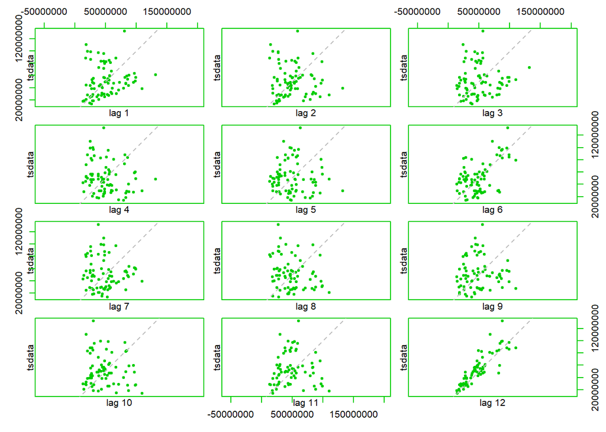

```r
lag.plot(tsdata, lags = 12, pch=19, do.lines = F, col = 3)
```

*ACF* can be written as:

$$r_k = \frac{\sum_{t=K+1}^T (y_t - \bar{y}) (y_{t-k} - \bar{y})}{\sum_{t=1}^T (y_t - \bar{y})^2}$$

The ACF between different lags are normally plotted to form the autocorrelation graphs or the correlogram. A sample of ACF is given below:

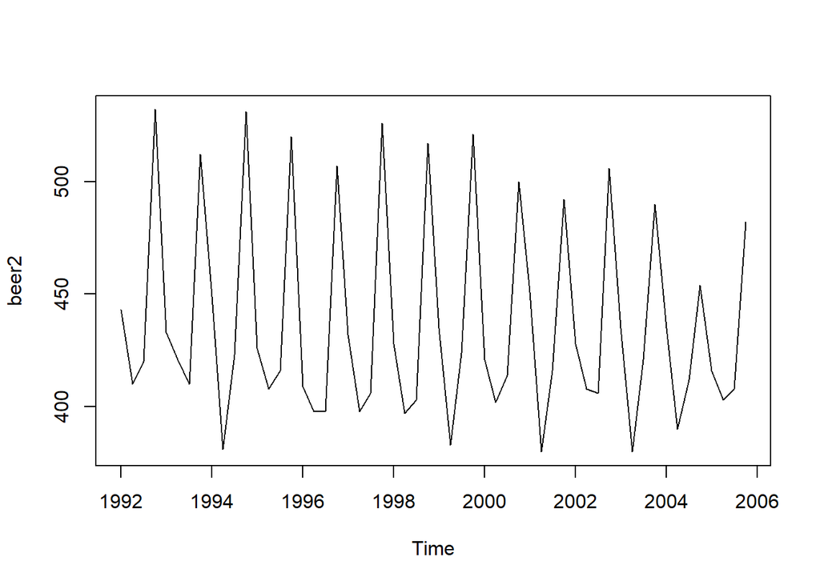

```r
beer2 <- window(ausbeer, start=1992, end=2006-.1)

plot(beer2)
```

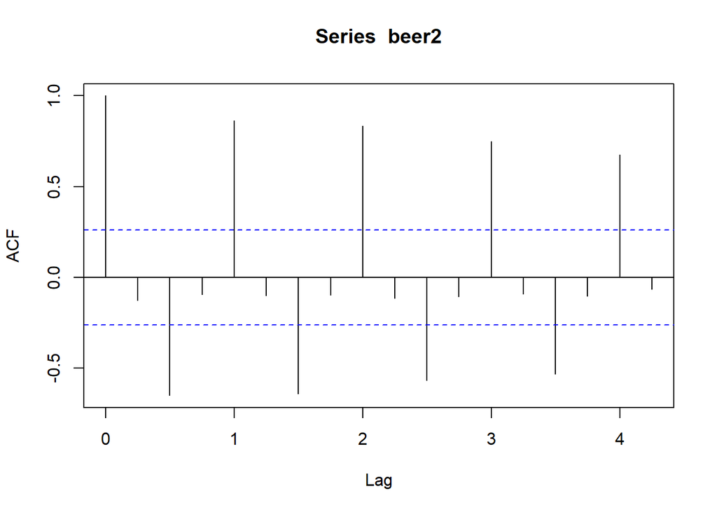

```r
acf(beer2)
```

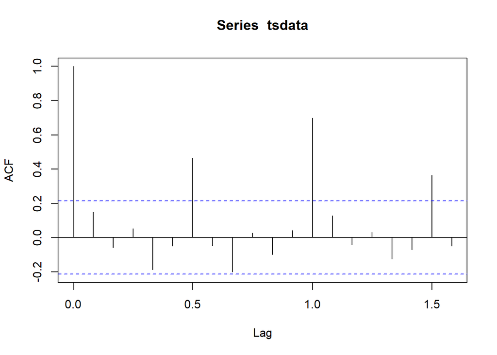

```r
acf(tsdata)
```

### WHITE NOISE

A scenario where a time series data shows no correlation.

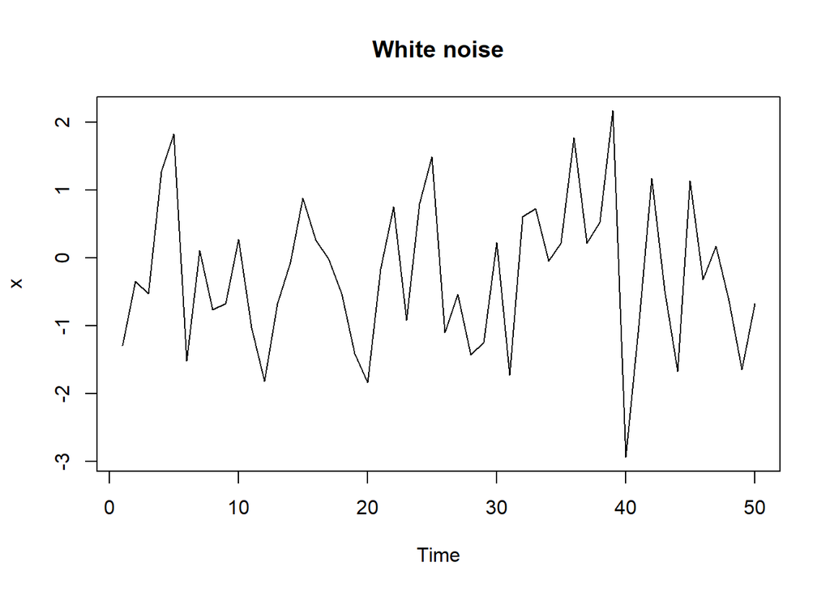

```r
set.seed(30)
x <- ts(rnorm(50))
plot(x, main="White noise")
```

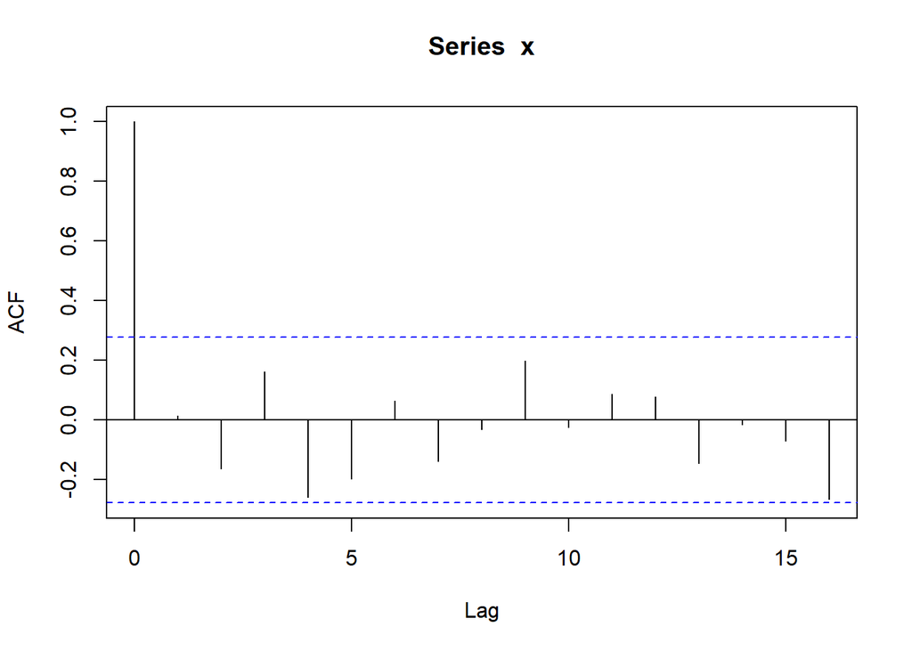

```r
acf(x)
```

In white noise, the expectation is that the ACF is close to zero. In other words, 95% of the ACF lies within $\pm \frac{2}{\sqrt{T}}$ where T is the length of time series

## SIMPLE FORECASTING METHODS

Some forecasting methods are very simple but surprisingly effective. There are four simple forecasting methods that can be used for benchmarking purpose.

### AVERAGE METHOD:

Simply done by taking the forecast of the historical values.

$$\hat{y}_{T+h|T} = \bar{y} = (y_1 + ... + y_T) / T$$

The average method is not only applicable to timeseries data, but also applicable for other cross sectional data. All the other methods are applicable only to Time Series data sets.

```r
meanf(tsdata, 12)
```

```
##          Point Forecast    Lo 80    Hi 80    Lo 95    Hi 95
## Sep 2017       50338159 18237942 82438376 915395.5 99760922
## Oct 2017       50338159 18237942 82438376 915395.5 99760922
## Nov 2017       50338159 18237942 82438376 915395.5 99760922
## Dec 2017       50338159 18237942 82438376 915395.5 99760922
## Jan 2018       50338159 18237942 82438376 915395.5 99760922
## Feb 2018       50338159 18237942 82438376 915395.5 99760922
## Mar 2018       50338159 18237942 82438376 915395.5 99760922
## Apr 2018       50338159 18237942 82438376 915395.5 99760922
## May 2018       50338159 18237942 82438376 915395.5 99760922
## Jun 2018       50338159 18237942 82438376 915395.5 99760922
## Jul 2018       50338159 18237942 82438376 915395.5 99760922
## Aug 2018       50338159 18237942 82438376 915395.5 99760922
```

### NAIVE METHOD

This method works on the pricinple that all future values are based on the last observed value ($y_T$). This works remarkable well for economic and financial timeseries.

```r
naive(tsdata, 12)
```

```
##          Point Forecast     Lo 80     Hi 80      Lo 95     Hi 95
## Sep 2017       67969243  26855344 109083141    5090961 130847525
## Oct 2017       67969243   9825410 126113076  -20954076 156892562
## Nov 2017       67969243  -3242119 139180604  -40939136 176877622
## Dec 2017       67969243 -14258555 150197040  -57787321 193725807
## Jan 2018       67969243 -23964230 159902715  -72630870 208569355
## Feb 2018       67969243 -32738830 168677316  -86050464 221988949
## Mar 2018       67969243 -40807909 176746394  -98391054 234329540
## Apr 2018       67969243 -48318424 184256909 -109877396 245815881
## May 2018       67969243 -55372453 191310939 -120665603 256604089
## Jun 2018       67969243 -62044321 197982806 -130869344 266807829
## Jul 2018       67969243 -68390133 204328618 -140574426 276512911
## Aug 2018       67969243 -74453480 210391965 -149847515 285786001
```

```r
rwf(tsdata, 12) #Alternate way
```

```
##          Point Forecast     Lo 80     Hi 80      Lo 95     Hi 95
## Sep 2017       67969243  26855344 109083141    5090961 130847525
## Oct 2017       67969243   9825410 126113076  -20954076 156892562
## Nov 2017       67969243  -3242119 139180604  -40939136 176877622
## Dec 2017       67969243 -14258555 150197040  -57787321 193725807
## Jan 2018       67969243 -23964230 159902715  -72630870 208569355
## Feb 2018       67969243 -32738830 168677316  -86050464 221988949
## Mar 2018       67969243 -40807909 176746394  -98391054 234329540
## Apr 2018       67969243 -48318424 184256909 -109877396 245815881
## May 2018       67969243 -55372453 191310939 -120665603 256604089
## Jun 2018       67969243 -62044321 197982806 -130869344 266807829
## Jul 2018       67969243 -68390133 204328618 -140574426 276512911
## Aug 2018       67969243 -74453480 210391965 -149847515 285786001
```

### SEASONAL NAIVE:

Forecast is said to be the last observed value from the previous season. This method works very good for seasonal data.

$$y_{t+h-km} \hspace{0.2cm} where\hspace{0.2cm}m=seasonal\hspace{0.2cm}period,\hspace{0.2cm}k={(h-1)/T}+1$$
where $k={(h-1)/T}$ is the integar part of the calculation.

```r
snaive(tsdata, 12)
```

```
##          Point Forecast    Lo 80    Hi 80     Lo 95    Hi 95
## Sep 2017       18340702  1205451 35475954  -7865403 44546808
## Oct 2017       14680243 -2455009 31815494 -11525863 40886348
## Nov 2017       24285606  7150355 41420858  -1920500 50491712
## Dec 2017       25014805  7879554 42150057  -1191300 51220911
## Jan 2018       36248740 19113489 53383992  10042635 62454846
## Feb 2018       71497956 54362705 88633208  45291850 97704062
## Mar 2018       47359364 30224113 64494616  21153258 73565470
## Apr 2018       30813250 13677999 47948502   4607144 57019356
## May 2018       44294777 27159525 61430028  18088671 70500882
## Jun 2018       18494100  1358848 35629351  -7712006 44700206
## Jul 2018       30170306 13035055 47305558   3964201 56376412
## Aug 2018       67969243 50833991 85104494  41763137 94175348
```

```r
tail(tsdata, 12) #For reference.
```

```
##           Jan      Feb      Mar      Apr      May      Jun      Jul
## 2016
## 2017 36248740 71497956 47359364 30813250 44294777 18494100 30170306
##           Aug      Sep      Oct      Nov      Dec
## 2016          18340702 14680243 24285606 25014805
## 2017 67969243
```

### Drift Method for forecasting

A variation of the Naive method where the forecasts are allowed to increase or decrease, based on the amount of change over time (the drift) is set to be the average change seen in the historical data

$$y_T+\frac{h}{T-1}\hspace{0.2cm}\sum_{t=2}^T\hspace{0.2cm}(y_t-y_{t-1})\hspace{0.2cm}=\hspace{0.2cm}y_T + h(\frac{y_T-y_1}{T-1})$$

This is equal to drawing a line from 1st observation to last observation, and extrapolating the line to predict the forecast.

```r
rwf(tsdata,12, drift = T)
```

```
##          Point Forecast     Lo 80     Hi 80      Lo 95     Hi 95
## Sep 2017       68435915  27076458 109795372    5182084 131689746
## Oct 2017       68902588  10060182 127744994  -21089106 158894282
## Nov 2017       69369261  -3125375 141863896  -41501717 180240238
## Dec 2017       69835933 -14364631 154036498  -58937717 198609584
## Jan 2018       70302606 -24382225 164987437  -74505347 215110559
## Feb 2018       70769279 -33547158 175085715  -88768943 230307501
## Mar 2018       71235951 -42077066 184548969 -102061354 244533257
## Apr 2018       71702624 -50112729 193517978 -114597882 258003130
## May 2018       72169297 -57751218 202089811 -126526984 270865577
## Jun 2018       72635969 -65062685 210334623 -137955949 283227888
## Jul 2018       73102642 -72099692 218304976 -148965165 295170449
## Aug 2018       73569315 -78902767 226041397 -159616612 306755242
```

*Comparing all different types of forecast, and see how they perform on predicting future values*

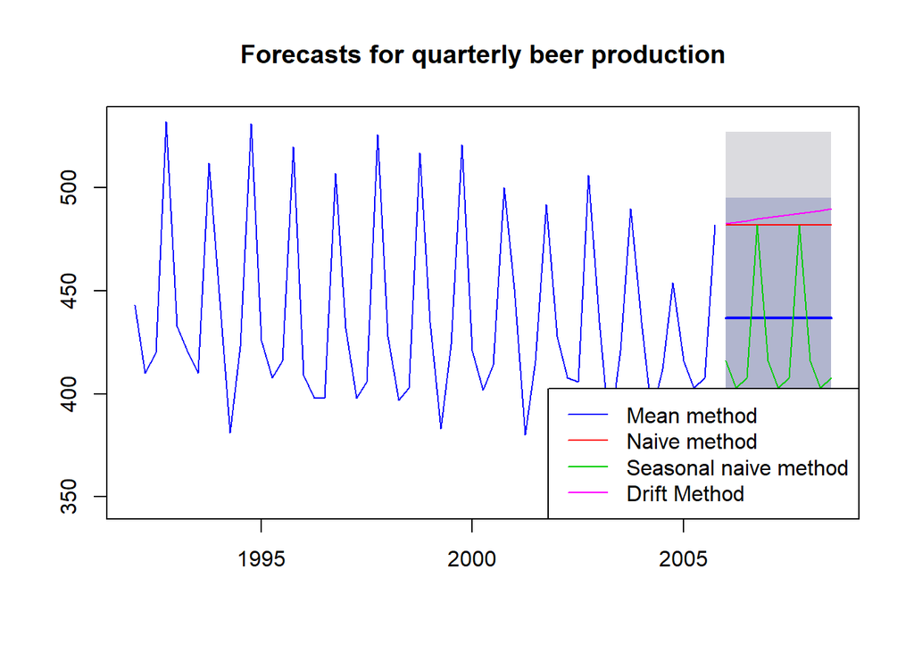

```r
beer2 <- window(ausbeer,start=1992,end=2006-.1)
beerfit1 <- meanf(beer2, h=11)
beerfit2 <- naive(beer2, h=11)
beerfit3 <- snaive(beer2, h=11)
beerfit4 <- rwf(beer2,h=11,drift=T)

plot(beerfit1,
  main="Forecasts for quarterly beer production", col=4)
lines(beerfit2$mean,col=2)
lines(beerfit3$mean,col=3)
lines(beerfit4$mean, col=6)
legend("bottomright",lty=1,col=c(4,2,3,6),
  legend=c("Mean method","Naive method","Seasonal naive method", "Drift Method"))
```

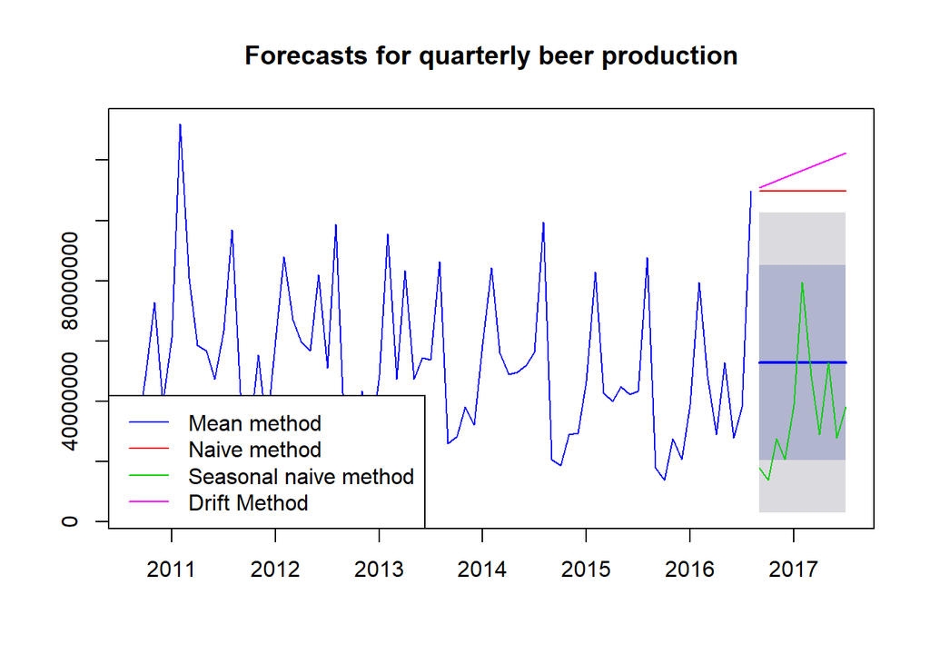

```r
### COMPARISON WITH SAMPLE TS DATA

ts2 <- window(tsdata,start=c(2010,9),end=c(2016,8))
tsfit1 <- meanf(ts2, h=11)
tsfit2 <- naive(ts2, h=11)
tsfit3 <- snaive(ts2, h=11)
tsfit4 <- rwf(ts2,h=11,drift=T)

plot(tsfit1,
  main="Forecasts for quarterly beer production", col=4)
lines(tsfit2$mean,col=2)
lines(tsfit3$mean,col=3)
lines(tsfit4$mean, col=6)
legend("bottomleft",lty=1,col=c(4,2,3,6),
  legend=c("Mean method","Naive method","Seasonal naive method", "Drift Method"))
```

## TRANSFORMATIONS AND ADJUSTMENTS:

**Transformations** are performed over time series data in order to simplify the pattern in the historical data by removing known variations or by making the patterns more consistent across the data. Four types of transformations exist: mathematical transformations, calendar adjustments, population adjustments, and inflation adjustments.

### MATHEMATICAL TRANSFORMATIONS

These are performed on time series which show an increasing or decreasing level. One such example of mathematical transformation is the lograthmic scale. If $y_t$ represents the time series data, then $w_t$ = $log(y_t)$.

These transformations help to reduce the extensive variations in the datasets. Other similar transformations can be square root or cube root.

The **Box-Cox transformation** is a commonly used transformation that includes both log and power transformation. They depend on the parameter $\lambda$.

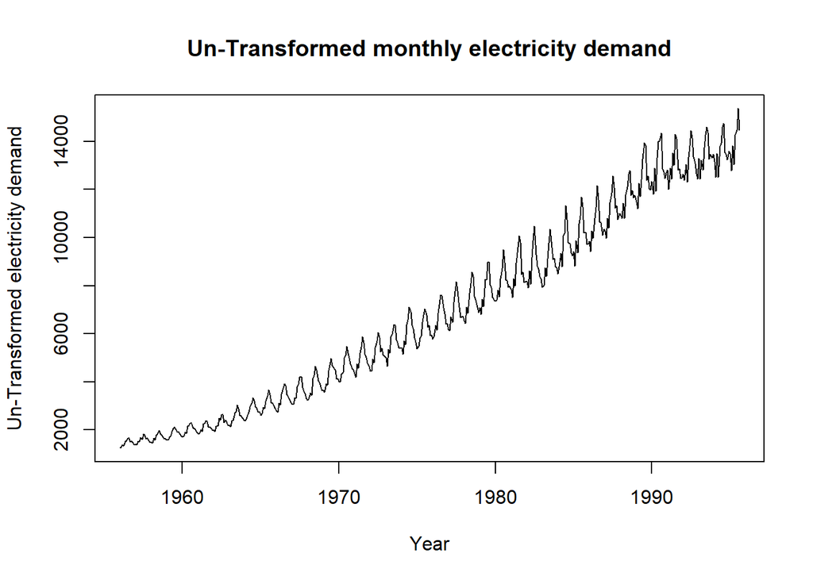

```r
plot(elec, ylab="Un-Transformed electricity demand",
 xlab="Year", main="Un-Transformed monthly electricity demand")
```

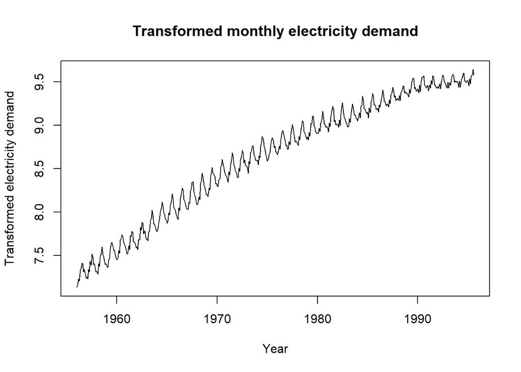

```r
plot(log(elec), ylab="Transformed electricity demand",
 xlab="Year", main="Transformed monthly electricity demand")
```

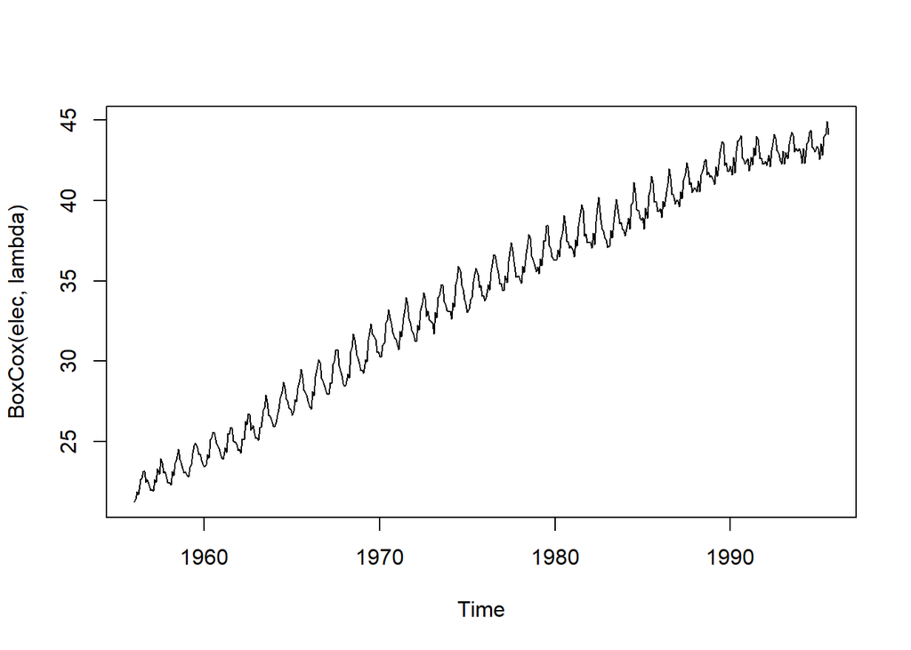

```r
# The BoxCox.lambda() function will choose a value of lambda for you.
lambda <- BoxCox.lambda(elec) # = 0.27
plot(BoxCox(elec,lambda))
```

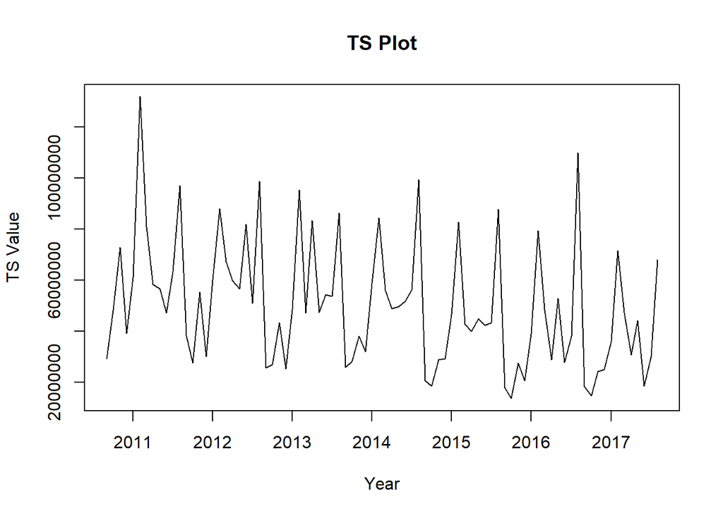

```r
plot(tsdata,main="TS Plot", xlab="Year", ylab="TS Value")
```

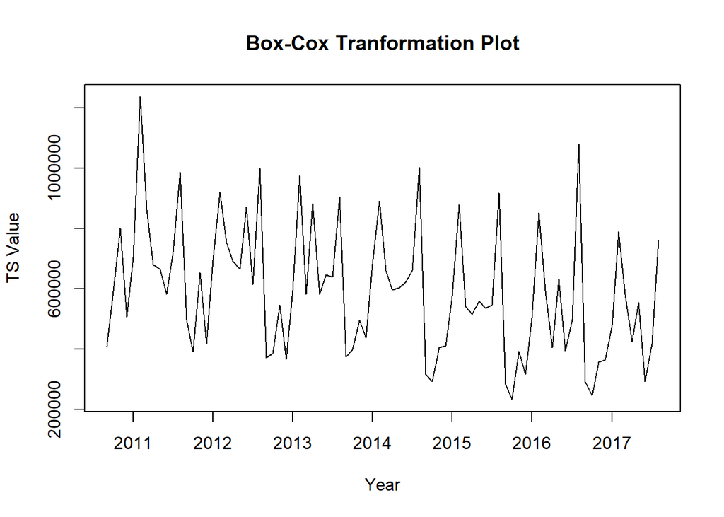

```r
# BOX COX FOR TSDATA

lambda <- BoxCox.lambda(tsdata)
plot(BoxCox(tsdata, lambda), main="Box-Cox Tranformation Plot", xlab="Year", ylab="TS Value")
```

In the above graphs, the season variation is not clearly visible in the actual dataset. However, the plots with the log, and box cox transformation show a clear pattern on seasonality throughtout the series. When the seasonlaity become similar across the trend, it becomes easier for the time series models to pick them when forecasting.

However, looking at the tsdata plot, a transformation may not be necessary.

### CALENDAR ADJUSTMENTS:

These adjustments are done to elimate the differences due to the calendar period. In the below scenario, there can be some differences on the monthly milk production due to variying month periods across the years. To eliminate this effect, when we calculate the average production of milk per day, the trend and seasonality is much more smoother

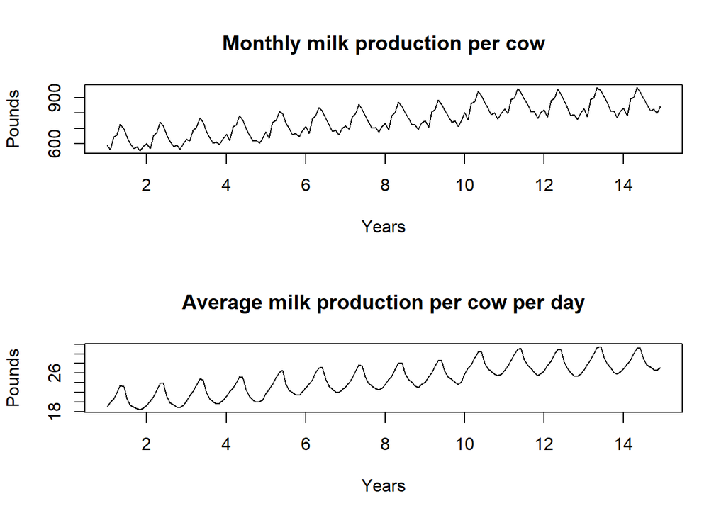

```r
data(milk)

monthdays <- rep(c(31,28,31,30,31,30,31,31,30,31,30,31),14)
 monthdays[26 + (4*12)*(0:2)] <- 29
par(mfrow=c(2,1))
plot(milk, main="Monthly milk production per cow",
   ylab="Pounds",xlab="Years")
plot(milk/monthdays, main="Average milk production per cow per day",
   ylab="Pounds", xlab="Years")
```

### POPULATION ADJUSTMENTS

In any data where population is related, it is best to take considerations on per capita basis rather than the total number. For instance, when studying the number of hospital beds in a region over time, it is always better to consider the number of beds available per 100 or 1000 individuals rather than total number of beds. This is to eliminate the population error: Consider that the beds are increasing in a region, however when the population increases much faster than the beds, though the number of beds increased as a whole, they are not enough for the growing population. Studying by per capita basis will eliminate this issue.

### INFLATION ADJUSTMENTS

A $200K house worth today is not the same 20 years ago. This is due to inflation changes. To make inflation adjustments, price index is used which are supplied usually by a government agency. If $z_t$ denotes the price index, and $y_t$ denotes the price of the house at time $t$, then $x_t$ = $y_t$/$z_t$*$z_2000$ gives the adjusted price of the house at year 2000 dollar values. For consumer goods, a common price index is Consumer Price Index (or CPI)

## Evaluating Forecast Accuracy:

###### Scale Dependent Errors:

The forecast error is simply $e_i$ = $y_i$ - $\hat{y_i}$ which is on the same scale on the data. Such errors are scale dependent, and cannot be used to compare between series that are on different scales.

The two most commonly used scale dependent measures are:

1. Mean Absolute Error: $MAE$ = $mean(|e_i|)$
2. Root Mean Square Error: $RMSE$ = $\sqrt{mean(|e_i^{2}|)}$

###### Percentage Errors:

Percentage Errors are scale independent, and so are frequently used to measure forecast performance between different datasets.$p_i = 100 * e_i/y_i$

Mean Absolute Percentage Error: $MAPE = mean(|p_i|)$

MAPE cannot be used when there are valid cases where the Actuals can be zero. For instance, the sales for a particular product may be seasonal and there are chances that the sales of the product is zero off season. Or, when forecasting temperature there are possibilities that the actual temperature can be zero. On such cases, the MAPE cannot be used as it may be equal to $\infty$

```r
beer3 <- window(ausbeer, start=2006)
accuracy(beerfit1, beer3)
```

```
##                                     ME     RMSE      MAE        MPE
## Training set   0.000000000000008121418 44.17630 35.91135 -0.9510944
## Test set     -17.183441558441550967018 38.01454 33.77760 -4.7345524
##                  MAPE     MASE        ACF1 Theil's U
## Training set 7.995509 2.444228 -0.12566970        NA
## Test set     8.169955 2.298999 -0.08286364 0.7901651
```

```r
accuracy(beerfit2, beer3)
```

```
##                       ME     RMSE      MAE         MPE     MAPE     MASE
## Training set   0.7090909 66.60207 55.43636  -0.8987351 12.26632 3.773156
## Test set     -62.2727273 70.90647 63.90909 -15.5431822 15.87645 4.349833
##                     ACF1 Theil's U
## Training set -0.25475212        NA
## Test set     -0.08286364  1.428524
```

```r
accuracy(beerfit3, beer3)
```

```
##                     ME     RMSE      MAE        MPE     MAPE      MASE
## Training set -1.846154 17.24261 14.69231 -0.4803931 3.401224 1.0000000
## Test set     -2.545455 12.96849 11.27273 -0.7530978 2.729847 0.7672537
##                    ACF1 Theil's U
## Training set -0.3408329        NA
## Test set     -0.1786912   0.22573
```

```r
accuracy(beerfit4, beer3)
```

```
##                                    ME     RMSE      MAE        MPE
## Training set   0.00000000000001240308 66.59830 55.50083  -1.062644
## Test set     -66.52727272727274510089 74.83196 67.64793 -16.567964
##                  MAPE     MASE        ACF1 Theil's U
## Training set 12.29043 3.777543 -0.25475212        NA
## Test set     16.79620 4.604310 -0.07101826  1.509823
```

Thus from the above, it is obvious that the snaive method has the best forecast accuracy among the rest.

###### Residual Diagnostics:

The difference between the predicted value and the actual value is called the residual. $Residual \space (e_i) = y_i - \hat{y_i}$.

A good forecating method will have the following characteristics of residuals: - The residuals are uncorrelated. If they are correlated, then there is some information in the residuals that should be used in determining forecast

- Mean of residual is zero. If not, then the forecast is biased.
- Residuals have constant variance
- Residuals are normally distributed

Fixing a forecast with a residual having a mean is easy. The forecast is adjusted by adding mean to all the predicted values.

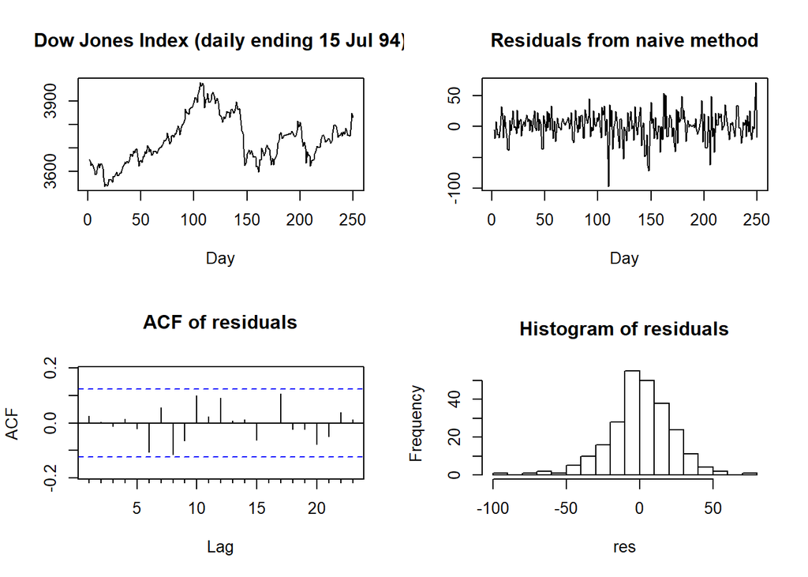

```r
dj2 <- window(dj, end=250)
par(mfrow = c(2,2))
plot(dj2, main="Dow Jones Index (daily ending 15 Jul 94)", ylab="", xlab="Day")
res <- residuals(naive(dj2))
plot(res, main="Residuals from naive method", ylab="", xlab="Day")
Acf(res, main="ACF of residuals")
hist(res, nclass="FD", main="Histogram of residuals")
```

From the graphs, it looks like there are no significant correlation in the residuals, which means all correlations are addressed in the forecast.

Some additional tests are available for testing the correlation:

Portmanteau test for correlation or the Box-Pierce test, and Ljung-Box test are used for checking if there are any correlations in the residuals, and if they are, are they due to sampling variation? A larger p-value supports the Null Hypothesis (i.e. any correlation existing are due to sampling variation, and that the population may be devoid of any correlation), whereas a smaller value rejects the Null Hypothesis, and suggests that the forecast can be improved by utilizing the correlation that are available within the residuals.

```r
# lag=h: h=10 for non seasonal dataset, or h = 2m for seasonal dataset, where m is the seasonal period
# fitdf = K: K is the number of parameters. Mostly for ts, K= 0
Box.test(res, lag=10, fitdf=0) # Box-Pierce Test
```

```
##
##  Box-Pierce test
##
## data:  res
## X-squared = 10.655, df = 10, p-value = 0.385
```

```r
Box.test(res,lag=10, fitdf=0, type="Lj") # Ljung-Box Test
```

```
##
##  Box-Ljung test
##
## data:  res
## X-squared = 11.088, df = 10, p-value = 0.3507
```

###### Prediction Intervals:

The range to which a prediction can vary is called the prediction Interval. We can have a 95% prediction interval, or 80% interval as required. If we are forecasting one step ahead, the sd of forecast is always almost equal to the sd of residuals, when there are no parameters involved in forecasting (in case of naive). When parameters do exist, the sd of forecast tend to be higher than residuals, but is very minimal difference that it is ignored.

Prediction Interval at 95%: $\hat{y_i}\space \pm \space 1.96\hat{\sigma}$ Prediction Interval at 80%: $\hat{y_i}\space \pm \space 1.28\hat{\sigma}$

where $\hat{y_i}$ is the estimated forecast, and $\hat{\sigma}$ is the estimate of sd of the forecast distribution. The multiplier 1.96 or 1.28 are for 95% and 80% respectively.For different percentage of prediction intervals, different multipliers to be used. (Additional information on the multiplier number is available here: $\href{https://www.otexts.org/fpp/2/7}{OTEXT LINK}$)

## SIMPLE REGRESSION

#### Simple Linear Model:

In this model, the forecast and predictor variables are assumed to be related by a simple linear model:

$y\space=\space\beta_0+\beta_1x+e$

Here, the parameter $\beta_0$ is the predicted value of y, when x = 0, and $\beta_1$ is the predicted increase of y, when x increases by 1 unit. In a linear model, the regression line is reprented by a straight line. However, in reality not all the observed values lie in a straight line. The distance between the predicted value along the regression line, and the observed value is the error or the residual. In other words, $\beta_0+\beta_1x$ captures the explanatory part or the systematic part, whereas $e$ captures the deviation from prediction or the random error.

In a good model, we assume that: - the errors sum up to zero, or the mean is equal to zero, else the forecast will be systematically biased - are not correlated, else there is information available in the errors that can be used in forecast - are unrelated to the predictor variable, else there is more information that is available in the error that should be used in the forecast

#### Least Square Estimation:

The optimal values for $\beta_0$ and $\beta_1$ can be determined by minimizing the sum of the squares of the errors.

$$\sum_{i=1}^N {e_i}^2 = \sum_{i=1}^N (y_i-\beta_0-\beta_1x_i)^2$$

#### Regression and Correlation:

Correlation and regression are closely associated with each other. The stronger the correlation exists between x and y, the more closer are the observed values lie along the regression line. The parameter $\beta_1$ can also be expressed as
$$\hat\beta_1 = r\frac{S_y}{S_x}$$

where, $S_y$ and $S_x$ are respective standard deviations.

Here is a simple way to draw a regression line:

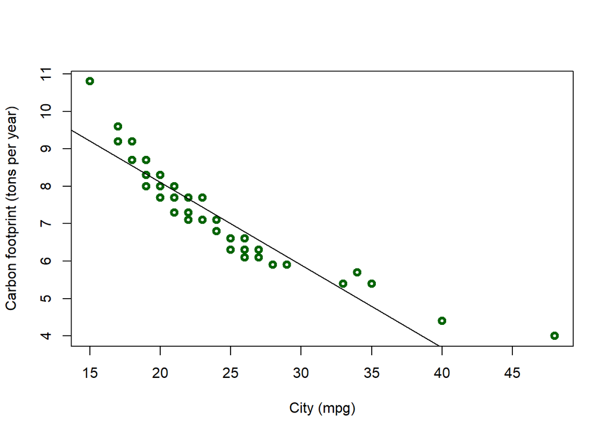

```r
plot(Carbon ~ City,xlab="City (mpg)",
  ylab="Carbon footprint (tons per year)",data=fuel, col="dark green", lwd =3)
fit <- lm(Carbon ~ City, data=fuel)
abline(fit)
```

```r
summary(fit)
```

```
##
## Call:
## lm(formula = Carbon ~ City, data = fuel)
##
## Residuals:
##     Min      1Q  Median      3Q     Max
## -0.7014 -0.3643 -0.1062  0.1938  2.0809
##
## Coefficients:
##              Estimate Std. Error t value            Pr(>|t|)
## (Intercept) 12.525647   0.199232   62.87 <0.0000000000000002 ***
## City        -0.220970   0.008878  -24.89 <0.0000000000000002 ***
## ---
## Signif. codes:  0 '***' 0.001 '**' 0.01 '*' 0.05 '.' 0.1 ' ' 1
##
## Residual standard error: 0.4703 on 132 degrees of freedom
## Multiple R-squared:  0.8244, Adjusted R-squared:  0.823
## F-statistic: 619.5 on 1 and 132 DF,  p-value: < 0.00000000000000022
```

#### Evaluating Regression Model:

For a good linear regression model, the predictor/regressor/independent variable and the dependent variable should be in linear relation, and the residuals should have a constant variance (i.e. homocedastic nature), and exhibit no to little correlation with the predictor variables.

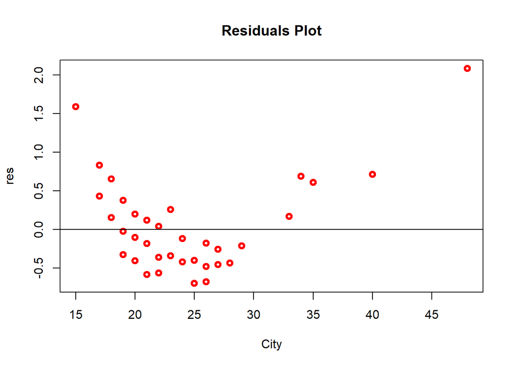

```r
res <- residuals(fit)
plot(res~City, main="Residuals Plot", data = fuel, col = "red", lwd = 3)
abline(0,0)
```

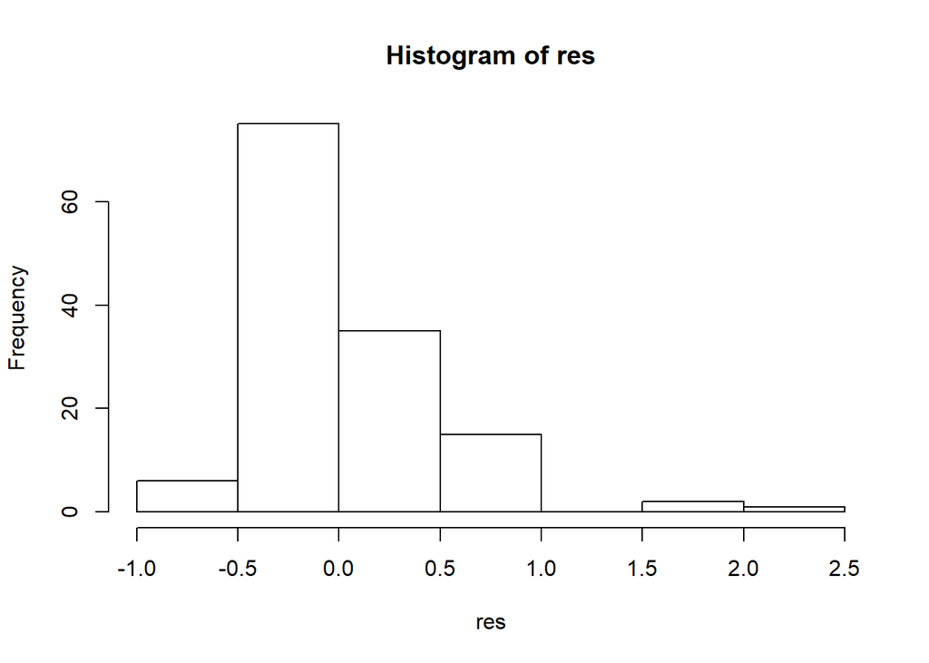

```r
hist(res)
```

From the above residual plot, it is obvious that they exhibit some kind of relation with the predictor variable, and is not homoscedastic, as it looks like some pattern exists within the plot. For instance, most of the lower and upper values of mpg have positive values, and the values between 20 and 30 mpg fall below 0. This suggests that a simple linear model is not not appropriate, and a non linear model is required.

An outlier that has an impact on the regression line is called influential observation. Though such outliers may have an impact on the regression line, it does not always leave a large residual. For clear understanding, refer $\href{https://www.otexts.org/fpp/2/7}{Influential\space Observation}$

**Goodness of fit:** In linear regressions, the goodness of a fit is measured with the help of $R^2$ which is nothing but the square of the correlation between the predicted values and the actual observations.

$$R^2 = \frac{\sum(\hat y_i - \bar y)^2}{\sum(y_i - \bar y)^2}$$
If the predictions are close to observed values, then the value of $R^2$ will be close to 1, else close to 0. $R^2$ lies between 1 and 0. In simple linear regression, the value of $R^2$ is also equal to the square of the correlation between y and x.

**Standard Error of the Regression**

This is one other measure to estimate the goodness of the model. This measure is obtained by calculating the standard deviation of the residuals.

$$s_e = \sqrt{\frac{1}{N-2} \sum^N_{i=1} e^2_i}$$

We have N-2, because there are two parameters involved in the linear regression. (i.e. the intercept and the slope). We can compare this error to the sample mean of yy or with the standard deviation of yy to gain some perspective on the accuracy of the model.

#### Forecasting With Regression:

The $\hat y$ obtatined by above are not true forecasts, as the x values are already observed values. The true forecast are generated when the prediction is carried out for unknown values of x, using the generated model.

Assuming that the residuals are normally distributed, an approximate 95% forecast interval is given by:

$\hat y \space \pm \space 1.96 s_e \sqrt {1+ \frac{1}{N} + \frac{(x- \bar x)^2}{(N-1)s_x^2}}$,

where N = Total Number of Observations $\bar x$ is the mean of the observed values $s_x$ is the SD of the observed values

Similarly, an 80% forecast interval can be obtained by replacing 1.96 by 1.28. The above equation shows that the forecast interval becomes wider when the value of x moves far away from mean of x. i.e. we are more certain on the forecast when the predictor variable is close to the sample mean.

The estimated regression line in the Car data example is $\hat y = 12.53−0.22x$.

For the Chevrolet Aveo (the first car in the list) $x_1$ = 25 mpg and $y_1$ =6.6 tons of CO2 per year. The model returns a fitted value of $\hat y_1$ = 7.00, i.e. $e_1$ = −0.4. For a car with City driving fuel economy $x$ =30 mpg, the average footprint forecasted is $\hat y$ = 5.90 tons of CO2 per year. The corresponding 95% and 80% forecast intervals are (4.95,6.84) and (5.28,6.51) respectively (calculated using R)

```r
#fitted(fit)[1]
#fcast <- forecast(fit, newdata=data.frame(City=30))
#plot(fcast, xlab="City (mpg)", ylab="Carbon footprint (tons per #year)")
# The displayed graph uses jittering, while the code above does not.
```

#### Statistical Inference: